# Interest Rates

Andrew Mahurin

05/21/2015

## Introduction

How much does interest rates affect the growth of money over time?

How do small changes in the interest rate affect the growth of a portfolio?

How does the interest rate paid compare with the interest earned from investments?

If a state government has a low interest rate on debt that it borrows, and a high interest rate on investments that it invests, how much should it invest?

see http://rmarkdown.rstudio.com.

## Goals

- To make a graph showing the amount of interest that can be earned by a state government that invests in the stock market.
- Actual returns will vary over time.
- To make a graph showing how much interest a state government would have to pay on debt incurred if it borrowed to invest in the stock market. *This may vary from state to state, depending on the situation.
- To demonstrate the benefits of investing in the stock market. *This won’t be an unbiased presentation.

## Introducing variables

```r
#example
max_time = 100
initial_balance = 1
year <- 1:100
a = b = initial_balance
interest_rate1 = 10
interest_rate2 = 1.5
deposit = 1
r1 = interest_rate1 / 100
r2 = interest_rate2 / 100
for (time in 2:(max_time-1)){
a[time] = a[time-1] * (1+r1) + deposit
b[time] = b[time-1] * (1+ r2) + deposit
}
a[max_time] = a[max_time-1] * (1+r1)
b[max_time] = b[max_time-1] * (1+ r2)
```

## Summarizing variables

```r
summary(cbind(a,b))
```

```
##        a                b
##  Min.   :     1   Min.   :  1.0
##  1st Qu.:   106   1st Qu.: 31.1
##  Median :  1223   Median : 74.7
##  Mean   : 15148   Mean   : 88.2
##  3rd Qu.: 13027   3rd Qu.:137.7
##  Max.   :137795   Max.   :227.8
```

## Plotting variables

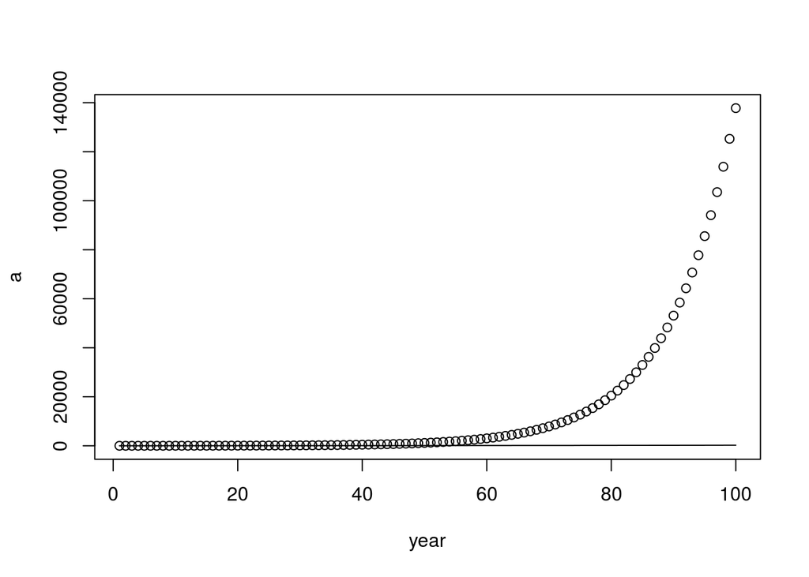

## Plotting the difference in account a and account b.

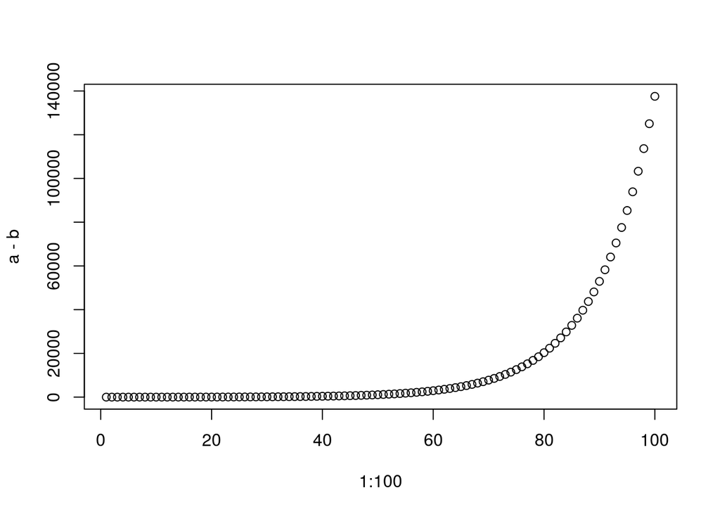

```r
plot(1:100,a-b)
```

## Changing the variables

A 5% interest rate would be equivalent to what a county would be expected to pay in interest.

```r
interest_rate2 = 5
r2 = .05
```

## Ploting the new results

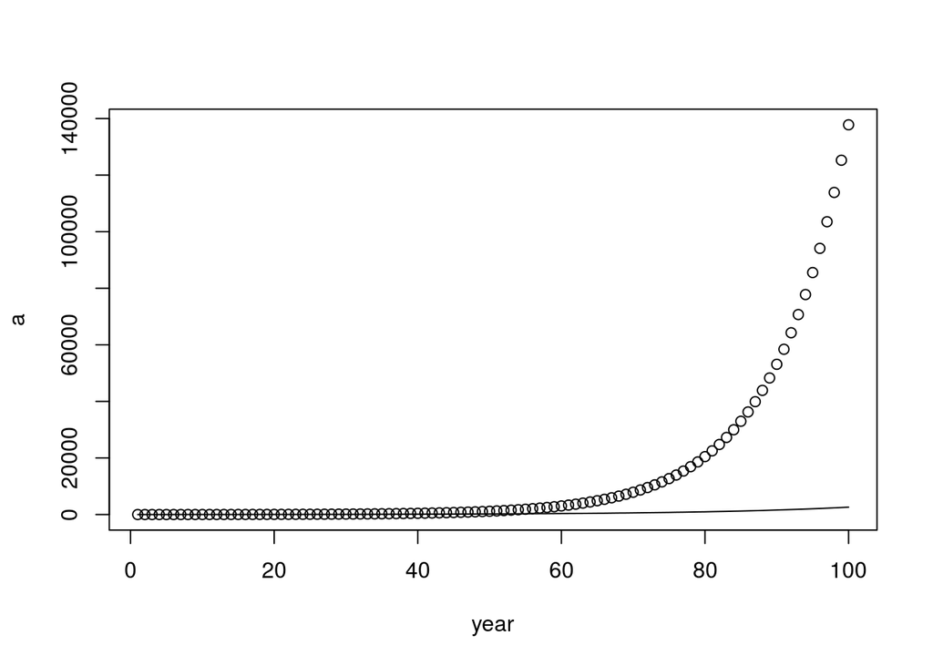